# Machine Learning Hackathon

### Distribution of numerical columns

#### **Customer ID is a unique column so we will remove the column while training the Model

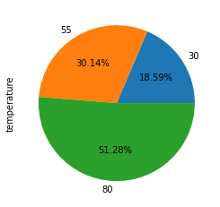

```python
# Distribution of temperature
data_train["temperature"].value_counts().sort_values(ascending=True).plot.pie(autopct = '%.2f%%')
```

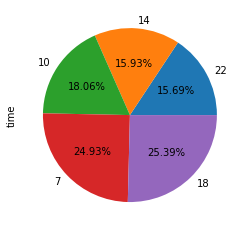

```python
# Distribution of time
data_train["time"].value_counts().sort_values(ascending=True).plot.pie(autopct = '%.2f%%')
```

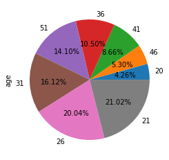

```python
# Distribution of age
data_train["age"].value_counts().sort_values(ascending=True).plot.pie(autopct = '%.2f%%')
```

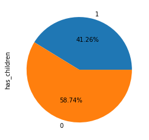

```python
# Distribution of has_children
data_train["has_children"].value_counts().sort_values(ascending=True).plot.pie(autopct = '%.2f%%')
```

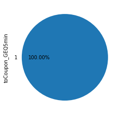

```python
# Distribution of toCoupon_GEQ5min
data_train["toCoupon_GEQ5min"].value_counts().sort_values(ascending=True).plot.pie(autopct = '%.2f%%')
```

```python
# As toCoupon_GEQ5min has only one constant value so we can remove it from train & test data
data_train.drop(columns = ["toCoupon_GEQ5min"], axis=1, inplace=True)
data_test.drop(columns = ["toCoupon_GEQ5min"], axis=1, inplace=True)
```

```python
data_train.info()
```

```
<class 'pandas.core.frame.DataFrame'>
RangeIndex: 10147 entries, 0 to 10146
Data columns (total 25 columns):
 #   Column                Non-Null Count  Dtype
---  ------                --------------  -----
 0   customer_id           10147 non-null  int64
 1   destination           10147 non-null  object
 2   passanger             10147 non-null  object
 3   weather               10147 non-null  object
 4   temperature           10147 non-null  int64
 5   time                  10147 non-null  int64
 6   coupon                10147 non-null  object
 7   expiration            10147 non-null  object
 8   gender                10147 non-null  object
 9   age                   10147 non-null  int64
```

[output cut: 17 more lines]

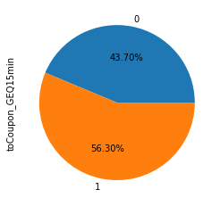

```python
# Distribution of toCoupon_GEQ15min
data_train["toCoupon_GEQ15min"].value_counts().sort_values(ascending=True).plot.pie(autopct = '%.2f%%')
```

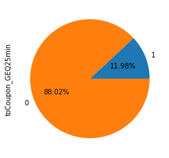

```python
# Distribution of toCoupon_GEQ25min
data_train["toCoupon_GEQ25min"].value_counts().sort_values(ascending=True).plot.pie(autopct = '%.2f%%')
```

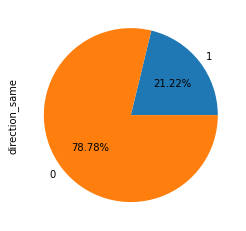

```python
# Distribution of direction_same
data_train["direction_same"].value_counts().sort_values(ascending=True).plot.pie(autopct = '%.2f%%')
```

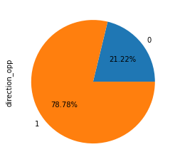

```python
# Distribution of direction_opp
data_train["direction_opp"].value_counts().sort_values(ascending=True).plot.pie(autopct = '%.2f%%')
```

## Bivariate Analysis

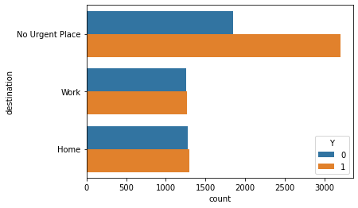

```python
#Checking how many Coupon Use with the destination
sns.countplot(y=data_train.destination, hue=data_train.Y)
```

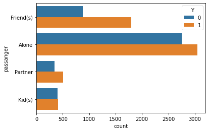

```python
#Checking how many Coupon Use with the passanger
sns.countplot(y=data_train.passanger, hue=data_train.Y)
```

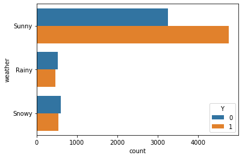

```python
#Checking how many Coupon Use with the weather
sns.countplot(y=data_train.weather, hue=data_train.Y)
```

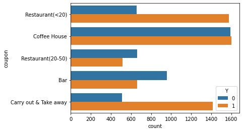

```python
#Checking how many Coupon Use with the coupon
sns.countplot(y=data_train.coupon, hue=data_train.Y)
```

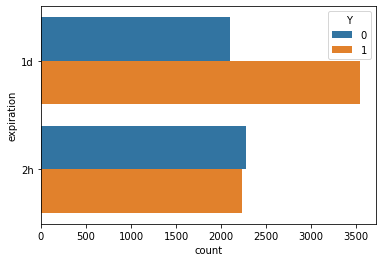

```python
#Checking how many Coupon Use with the expiration
sns.countplot(y=data_train.expiration, hue=data_train.Y)
```

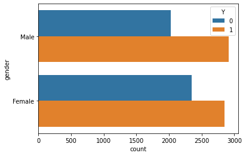

```python
#Checking how many Coupon Use with the gender
sns.countplot(y=data_train.gender, hue=data_train.Y)
```

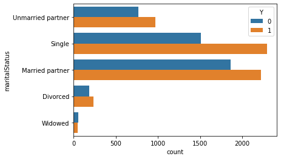

```python
#Checking how many Coupon Use with the maritalStatus
sns.countplot(y=data_train.maritalStatus, hue=data_train.Y)
```

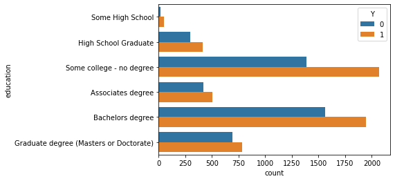

```python
#Checking how many Coupon Use with the education
sns.countplot(y=data_train.education, hue=data_train.Y, order = education_order)
```

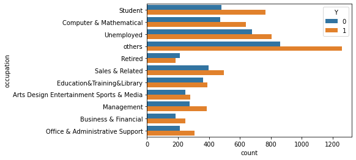

```python
#Checking how many Coupon Use with the occupation
sns.countplot(y=data_train.occupation, hue=data_train.Y)
```

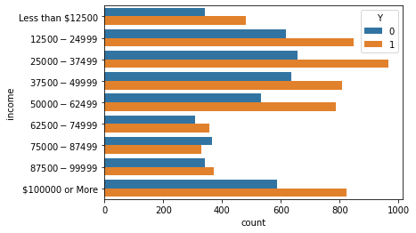

```python
#Checking how many Coupon Use with the income
sns.countplot(y=data_train.income, hue=data_train.Y, order = income_order)
```

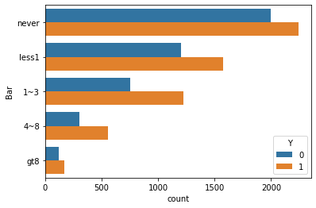

```python
#Checking how many Coupon Use with the Bar
sns.countplot(y=data_train.Bar, hue=data_train.Y, order = bar_order)
```

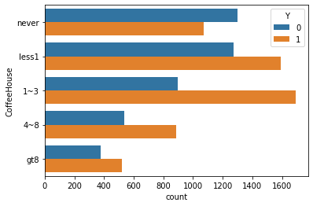

```python
#Checking how many Coupon Use with the CoffeeHouse
sns.countplot(y=data_train.CoffeeHouse, hue=data_train.Y, order = CoffeeHouse_order)
```

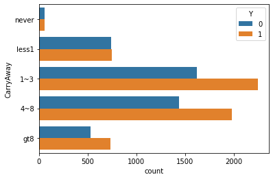

```python
#Checking how many Coupon Use with the CarryAway
sns.countplot(y=data_train.CarryAway, hue=data_train.Y, order = CarryAway_order)
```

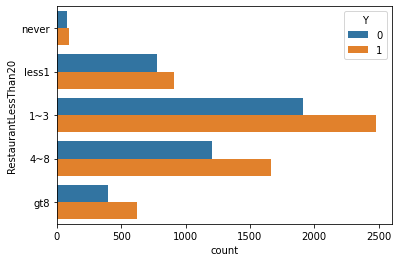

```python
#Checking how many Coupon Use with the RestaurantLessThan20
sns.countplot(y=data_train.RestaurantLessThan20, hue=data_train.Y, order = RestaurantLessThan20_order)
```

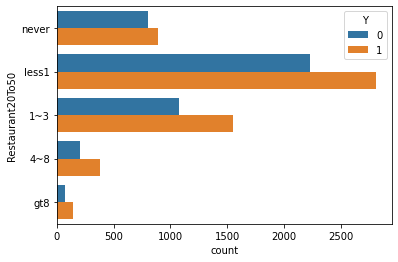

```python
#Checking how many Coupon Use with the Restaurant20To50
sns.countplot(y=data_train.Restaurant20To50, hue=data_train.Y, order = Restaurant20To50_order)
```

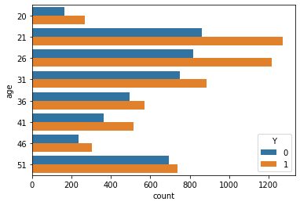

```python
#Checking how many Coupon Use with the age
sns.countplot(y=data_train.age, hue=data_train.Y)
```

```python
pd.crosstab(index = data_train['age'], columns = data_train['Y'])
```

| Y age | 0 | 1 |
| --- | --- | --- |
| 20 | 164 | 268 |
| 21 | 862 | 1271 |
| 26 | 817 | 1216 |
| 31 | 751 | 885 |
| 36 | 495 | 570 |
| 41 | 363 | 516 |
| 46 | 235 | 303 |
| 51 | 692 | 739 |

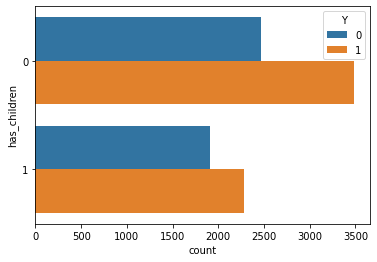

```python
#Checking how many Coupon Use with the has_children
sns.countplot(y=data_train.has_children, hue=data_train.Y)
```

```python
pd.crosstab(index = data_train['has_children'], columns = data_train['Y'])
```

| Y has_children | 0 | 1 |
| --- | --- | --- |
| 0 | 2471 | 3489 |
| 1 | 1908 | 2279 |

### ***Conclusion of Bi-variate analysis

### ***We can say that there is a High Usages of Coupon when:

```
- Destination is "No Urgent Place".
- Passanger is "Alone".
- Weather is Sunny.
- Coupon are Coffee House, Carry Out and Restaurent (<20).
- Expiration is "1 Day".
- "Marital Status" is "Single" or "Married Partner".
- Education is "Some college - No degree" or "Bachelors degree".
- Occupation is "Student" or "Unemployed" or "Others".
- Income range "$25000 - $37499" or "$37500 - $49999" or "$12500 - $24999" or "$100000 or More".

- Never go to Bar.
- Go to a Cofee House in between 1 to 3 times.
- Get Take-Away food in between 1 to 3 times.
- Go to a restaurant with an average expense per person of less than $20 in between 1 to 3 times.

- Go to a restaurant with an average expense per person of $20 - $50, less than 1 time
- Age group from 21 to 31 and 50+.
- No Children (Has_Children is zero).
```

### Multivariate Analysis

```python
# Check all Vriable Type
pd.DataFrame(data_train.nunique()).sort_values(0).rename( {0: 'Unique Values'}, axis=1)
```

|  | Unique Values |
| --- | --- |
| Y | 2 |
| toCoupon_GEQ15min | 2 |
| toCoupon_GEQ25min | 2 |
| direction_opp | 2 |
| has_children | 2 |
| gender | 2 |
| expiration | 2 |
| direction_same | 2 |
| temperature | 3 |
| weather | 3 |
| destination | 3 |
| passanger | 4 |
| time | 5 |
| RestaurantLessThan20 | 5 |
| maritalStatus | 5 |
| Bar | 5 |
| CoffeeHouse | 5 |
| CarryAway | 5 |
| coupon | 5 |
| Restaurant20To50 | 5 |
| education | 6 |
| age | 8 |
| income | 9 |
| occupation | 11 |
| customer_id | 10147 |

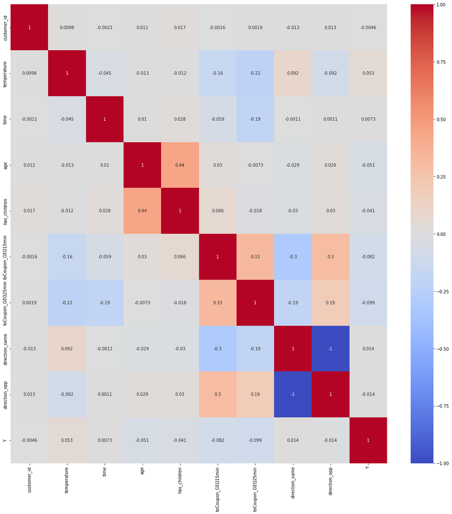

```python
#Calculate the correlation for the dataset (Numeric values)
corr = data_train.corr()

#Setting the size of the figure
fig, ax = plt.subplots(figsize = (20,20))

#Plot the correlation using heatmap
sns.heatmap(corr, annot=True, cmap = 'coolwarm')
```

#### ***If you look at the data, direction_same and direction_opp are inversely corelated, hence dropping one of the columns

```python
data_train.drop(axis=1,columns=['direction_opp'],inplace=True)
data_test.drop(axis=1,columns=['direction_opp'],inplace=True)
print("Shape of Train Data:", data_train.shape)
print("Shape of Test Data:", data_test.shape)
```

```
Shape of Train Data: (10147, 24)
Shape of Test Data: (2537, 23)
```

## Encoding the Categorical Variables

```python
#make a copy of data_train and data_test
#data_train_c = data_train.copy()
#data_test_c = data_test.copy()
```

```python
# Ordinal Encoding for income
#income_mapper = {"Less than $12500": 1, "$12500 - $24999": 2, "$25000 - $37499": 3, "$37500 - $49999": 4, "$50000 - $62499": 5, "$62500 - $74999": 6, "$75000 - $87499": 7, "$87500 - $99999": 8, "$100000 or More": 9}
#data_train["income"] = data_train["income"].replace(income_mapper)
#data_test["income"] = data_test["income"].replace(income_mapper)
```

```python
# Ordinal Encoding for Education
#education_mapper = {"Some High School": 1, "High School Graduate": 2, "Some college - no degree": 3, "Associates degree": 4, "Bachelors degree": 5, "Graduate degree (Masters or Doctorate)": 6}
#data_train["education"] = data_train["education"].replace(education_mapper)
#data_test["education"] = data_test["education"].replace(education_mapper)
```

```python
# Ordinal Encoding for Bar, CoffeeHouse, CarryAway, RestaurantLessThan20, Restaurant20To50
#general_mapper = {"never": 1, "less1": 2, "1~3": 3, "4~8": 4, "gt8": 5}

#data_train["Bar"] = data_train["Bar"].replace(general_mapper)
#data_train["CoffeeHouse"] = data_train["CoffeeHouse"].replace(general_mapper)
#data_train["CarryAway"] = data_train["CarryAway"].replace(general_mapper)
#data_train["RestaurantLessThan20"] = data_train["RestaurantLessThan20"].replace(general_mapper)
#data_train["Restaurant20To50"] = data_train["Restaurant20To50"].replace(general_mapper)

#data_test["Bar"] = data_test["Bar"].replace(general_mapper)
#data_test["CoffeeHouse"] = data_test["CoffeeHouse"].replace(general_mapper)
#data_test["CarryAway"] = data_test["CarryAway"].replace(general_mapper)
#data_test["RestaurantLessThan20"] = data_test["RestaurantLessThan20"].replace(general_mapper)
#data_test["Restaurant20To50"] = data_test["Restaurant20To50"].replace(general_mapper)
```

```python
# converting categorical columns to Numerical column
data_train_dummies = pd.get_dummies(data_train)
data_test_dummies = pd.get_dummies(data_test)
```

```python
print("Shape of Train Data:", data_train_dummies.shape)
print("Shape of Test Data:", data_test_dummies.shape)
```

```
Shape of Train Data: (10147, 84)
Shape of Test Data: (2537, 83)
```

```python
data_train_dummies.info()
```

```
<class 'pandas.core.frame.DataFrame'>
RangeIndex: 10147 entries, 0 to 10146
Data columns (total 84 columns):
 #   Column                                               Non-Null Count  Dtype
---  ------                                               --------------  -----
 0   customer_id                                          10147 non-null  int64
 1   temperature                                          10147 non-null  int64
 2   time                                                 10147 non-null  int64
 3   age                                                  10147 non-null  int64
 4   has_children                                         10147 non-null  int64
 5   toCoupon_GEQ15min                                    10147 non-null  int64
 6   toCoupon_GEQ25min                                    10147 non-null  int64
 7   direction_same                                       10147 non-null  int64
 8   Y                                                    10147 non-null  int64
 9   destination_Home                                     10147 non-null  uint8
```

[output cut: 76 more lines]

```python
# Correlation of the numeric columns
data_train_dummies.corr().style.background_gradient()
```

|  | customer_id | temperature | time | age | has_children | toCoupon_GEQ15min | toCoupon_GEQ25min | direction_same | Y | destination_Home | destination_No Urgent Place | destination_Work | passanger_Alone | passanger_Friend(s) | passanger_Kid(s) | passanger_Partner | weather_Rainy | weather_Snowy | weather_Sunny | coupon_Bar | coupon_Carry out & Take away | coupon_Coffee House | coupon_Restaurant(20-50) | coupon_Restaurant(<20) | expiration_1d | expiration_2h | gender_Female | gender_Male | maritalStatus_Divorced | … |
| --- | --- | --- | --- | --- | --- | --- | --- | --- | --- | --- | --- | --- | --- | --- | --- | --- | --- | --- | --- | --- | --- | --- | --- | --- | --- | --- | --- | --- | --- | --- |
| customer_id | 1.000000 | 0.009802 | -0.002119 | 0.012083 | 0.016644 | -0.001647 | 0.001947 | -0.012535 | -0.004595 | -0.010415 | 0.007181 | 0.002172 | -0.002515 | -0.011779 | 0.010024 | 0.013363 | -0.011543 | 0.001725 | 0.007069 | -0.001004 | -0.006585 | -0.007504 | 0.020527 | -0.000339 | -0.002080 | 0.002080 | -0.002521 | 0.002521 | -0.008541 | … |
| temperature | 0.009802 | 1.000000 | -0.045365 | -0.012911 | -0.012415 | -0.155627 | -0.215181 | 0.092184 | 0.053147 | -0.056184 | 0.136521 | -0.101287 | -0.107612 | 0.110835 | 0.024010 | -0.007607 | -0.139724 | -0.614258 | 0.578290 | -0.131952 | -0.131282 | 0.171864 | 0.033304 | 0.022587 | -0.125488 | 0.125488 | 0.027896 | -0.027896 | 0.025611 | … |
| time | -0.002119 | -0.045365 | 1.000000 | 0.010268 | 0.028134 | -0.059183 | -0.189059 | -0.001125 | 0.007258 | 0.599470 | 0.106539 | -0.725884 | -0.227345 | 0.168613 | 0.080379 | 0.058901 | -0.022240 | -0.001021 | 0.016991 | 0.026941 | -0.051240 | -0.075587 | 0.063034 | 0.060628 | -0.028632 | 0.028632 | -0.006179 | 0.006179 | -0.009258 | … |
| age | 0.012083 | -0.012911 | 0.010268 | 1.000000 | 0.443809 | 0.029903 | -0.007263 | -0.028568 | -0.051105 | -0.011168 | 0.028349 | -0.021534 | -0.034668 | -0.009614 | 0.113666 | -0.034146 | -0.012082 | 0.004712 | 0.005145 | -0.001354 | 0.000339 | -0.016449 | 0.020374 | 0.003565 | -0.016074 | 0.016074 | 0.100864 | -0.100864 | 0.200265 | … |
| has_children | 0.016644 | -0.012415 | 0.028134 | 0.443809 | 1.000000 | 0.065631 | -0.017729 | -0.029574 | -0.040851 | -0.005198 | 0.024927 | -0.023582 | -0.055466 | -0.050975 | 0.341295 | -0.154077 | -0.023280 | -0.003312 | 0.019526 | 0.012721 | 0.010473 | -0.036093 | 0.028337 | -0.002615 | -0.013898 | 0.013898 | 0.155253 | -0.155253 | 0.209681 | … |
| toCoupon_GEQ15min | -0.001647 | -0.155627 | -0.059183 | 0.029903 | 0.065631 | 1.000000 | 0.325074 | -0.300418 | -0.081642 | -0.137527 | 0.038763 | 0.093482 | -0.139197 | 0.130917 | 0.117543 | -0.074664 | 0.073392 | 0.107522 | -0.136868 | 0.091177 | 0.070116 | -0.059741 | 0.051699 | -0.120007 | -0.042046 | 0.042046 | 0.000805 | -0.000805 | 0.011229 | … |
| toCoupon_GEQ25min | 0.001947 | -0.215181 | -0.189059 | -0.007263 | -0.017729 | 0.325074 | 1.000000 | -0.191495 | -0.098778 | 0.047977 | -0.366925 | 0.375819 | 0.277003 | -0.220836 | -0.102270 | -0.043108 | 0.123086 | 0.181610 | -0.230538 | 0.181710 | -0.011962 | -0.091107 | -0.052167 | -0.007031 | 0.033440 | -0.033440 | -0.003423 | 0.003423 | 0.015328 | … |
| direction_same | -0.012535 | 0.092184 | -0.001125 | -0.028568 | -0.029574 | -0.300418 | -0.191495 | 1.000000 | 0.014182 | 0.359776 | -0.516060 | 0.234667 | 0.376033 | -0.310594 | -0.114220 | -0.065441 | 0.019448 | -0.063542 | 0.035128 | -0.011422 | 0.135294 | -0.036895 | -0.035934 | -0.048757 | -0.029273 | 0.029273 | 0.009071 | -0.009071 | 0.004275 | … |
| Y | -0.004595 | 0.053147 | 0.007258 | -0.051105 | -0.040851 | -0.081642 | -0.098778 | 0.014182 | 1.000000 | -0.074576 | 0.131406 | -0.076882 | -0.100172 | 0.125912 | -0.039346 | 0.017177 | -0.065554 | -0.064951 | 0.098134 | -0.140365 | 0.162912 | -0.091667 | -0.095728 | 0.146805 | 0.133069 | -0.133069 | -0.041871 | 0.041871 | -0.005053 | … |
| destination_Home | -0.010415 | -0.056184 | 0.599470 | -0.011168 | -0.005198 | -0.137527 | 0.047977 | 0.359776 | -0.074576 | 1.000000 | -0.579435 | -0.335825 | 0.358200 | -0.348737 | -0.072001 | -0.014452 | -0.032785 | 0.027623 | 0.002450 | -0.005802 | 0.024608 | -0.028220 | 0.146213 | -0.099531 | 0.009415 | -0.009415 | 0.012202 | -0.012202 | 0.003768 | … |
| destination_No Urgent Place | 0.007181 | 0.136521 | 0.106539 | 0.028349 | 0.024927 | 0.038763 | -0.366925 | -0.516060 | 0.131406 | -0.579435 | 1.000000 | -0.573098 | -0.743183 | 0.601857 | 0.209914 | 0.163842 | -0.038009 | -0.096541 | 0.102577 | 0.009173 | -0.082027 | 0.053685 | -0.152157 | 0.126921 | -0.065320 | 0.065320 | -0.013164 | 0.013164 | -0.012241 | … |
| destination_Work | 0.002172 | -0.101287 | -0.725884 | -0.021534 | -0.023582 | 0.093482 | 0.375819 | 0.234667 | -0.076882 | -0.335825 | -0.573098 | 1.000000 | 0.498740 | -0.344923 | -0.170204 | -0.174822 | 0.076892 | 0.083799 | -0.121014 | -0.004767 | 0.070056 | -0.033670 | 0.028834 | -0.046608 | 0.066025 | -0.066025 | 0.002945 | -0.002945 | 0.010359 | … |
| passanger_Alone | -0.002515 | -0.107612 | -0.227345 | -0.034668 | -0.055466 | -0.139197 | 0.277003 | 0.376033 | -0.100172 | 0.358200 | -0.743183 | 0.498740 | 1.000000 | -0.691588 | -0.341268 | -0.350528 | 0.072439 | 0.110922 | -0.138812 | 0.015201 | 0.012420 | -0.012696 | 0.063440 | -0.060005 | 0.118401 | -0.118401 | 0.002543 | -0.002543 | 0.030662 | … |
| passanger_Friend(s) | -0.011779 | 0.110835 | 0.168613 | -0.009614 | -0.050975 | 0.130917 | -0.220836 | -0.310594 | 0.125912 | -0.348737 | 0.601857 | -0.344923 | -0.691588 | 1.000000 | -0.176748 | -0.181544 | -0.109354 | -0.066643 | 0.131349 | -0.092754 | 0.053562 | 0.070547 | -0.119712 | 0.044864 | -0.106770 | 0.106770 | -0.027033 | 0.027033 | 0.002284 | … |
| passanger_Kid(s) | 0.010024 | 0.024010 | 0.080379 | 0.113666 | 0.341295 | 0.117543 | -0.102270 | -0.114220 | -0.039346 | -0.072001 | 0.209914 | -0.170204 | -0.341268 | -0.176748 | 1.000000 | -0.089584 | -0.016407 | -0.045474 | 0.047228 | 0.039395 | -0.031720 | -0.071095 | 0.062972 | 0.026156 | -0.009994 | 0.009994 | 0.046840 | -0.046840 | -0.006309 | … |
| passanger_Partner | 0.013363 | -0.007607 | 0.058901 | -0.034146 | -0.154077 | -0.074664 | -0.043108 | -0.065441 | 0.017177 | -0.014452 | 0.163842 | -0.174822 | -0.350528 | -0.181544 | -0.089584 | 1.000000 | 0.060478 | -0.047403 | -0.007276 | 0.081537 | -0.076072 | -0.019774 | 0.015317 | 0.010143 | -0.031767 | 0.031767 | -0.007450 | 0.007450 | -0.052074 | … |
| weather_Rainy | -0.011543 | -0.139724 | -0.022240 | -0.012082 | -0.023280 | 0.073392 | 0.123086 | 0.019448 | -0.065554 | -0.032785 | -0.038009 | 0.076892 | 0.072439 | -0.109354 | -0.016407 | 0.060478 | 1.000000 | -0.117093 | -0.637528 | 0.176367 | 0.059644 | -0.089653 | -0.065172 | -0.061621 | -0.039149 | 0.039149 | -0.019756 | 0.019756 | -0.011184 | … |
| weather_Snowy | 0.001725 | -0.614258 | -0.001021 | 0.004712 | -0.003312 | 0.107522 | 0.181610 | -0.063542 | -0.064951 | 0.027623 | -0.096541 | 0.083799 | 0.110922 | -0.066643 | -0.045474 | -0.047403 | -0.117093 | 1.000000 | -0.690477 | 0.007944 | 0.025123 | -0.070609 | 0.003441 | 0.045678 | 0.112288 | -0.112288 | -0.024760 | 0.024760 | -0.014030 | … |
| weather_Sunny | 0.007069 | 0.578290 | 0.016991 | 0.005145 | 0.019526 | -0.136868 | -0.230538 | 0.035128 | 0.098134 | 0.002450 | 0.102577 | -0.121014 | -0.138812 | 0.131349 | 0.047228 | -0.007276 | -0.637528 | -0.690477 | 1.000000 | -0.134623 | -0.062932 | 0.120076 | 0.044799 | 0.009447 | -0.058594 | 0.058594 | 0.033598 | -0.033598 | 0.019030 | … |
| coupon_Bar | -0.001004 | -0.131952 | 0.026941 | -0.001354 | 0.012721 | 0.091177 | 0.181710 | -0.011422 | -0.140365 | -0.005802 | 0.009173 | -0.004767 | 0.015201 | -0.092754 | 0.039395 | 0.081537 | 0.176367 | 0.007944 | -0.134623 | 1.000000 | -0.211002 | -0.295543 | -0.158063 | -0.231784 | 0.192323 | -0.192323 | -0.000739 | 0.000739 | -0.014490 | … |
| coupon_Carry out & Take away | -0.006585 | -0.131282 | -0.051240 | 0.000339 | 0.010473 | 0.070116 | -0.011962 | 0.135294 | 0.162912 | 0.024608 | -0.082027 | 0.070056 | 0.012420 | 0.053562 | -0.031720 | -0.076072 | 0.059644 | 0.025123 | -0.062932 | -0.211002 | 1.000000 | -0.327515 | -0.175162 | -0.256859 | 0.050395 | -0.050395 | 0.003405 | -0.003405 | 0.017699 | … |
| coupon_Coffee House | -0.007504 | 0.171864 | -0.075587 | -0.016449 | -0.036093 | -0.059741 | -0.091107 | -0.036895 | -0.091667 | -0.028220 | 0.053685 | -0.033670 | -0.012696 | 0.070547 | -0.071095 | -0.019774 | -0.089653 | -0.070609 | 0.120076 | -0.295543 | -0.327515 | 1.000000 | -0.245344 | -0.359774 | -0.157040 | 0.157040 | 0.005716 | -0.005716 | -0.009770 | … |
| coupon_Restaurant(20-50) | 0.020527 | 0.033304 | 0.063034 | 0.020374 | 0.028337 | 0.051699 | -0.052167 | -0.035934 | -0.095728 | 0.146213 | -0.152157 | 0.028834 | 0.063440 | -0.119712 | 0.062972 | 0.015317 | -0.065172 | 0.003441 | 0.044799 | -0.158063 | -0.175162 | -0.245344 | 1.000000 | -0.192415 | 0.053545 | -0.053545 | -0.007781 | 0.007781 | -0.003674 | … |
| coupon_Restaurant(<20) | -0.000339 | 0.022587 | 0.060628 | 0.003565 | -0.002615 | -0.120007 | -0.007031 | -0.048757 | 0.146805 | -0.099531 | 0.126921 | -0.046608 | -0.060005 | 0.044864 | 0.026156 | 0.010143 | -0.061621 | 0.045678 | 0.009447 | -0.231784 | -0.256859 | -0.359774 | -0.192415 | 1.000000 | -0.083226 | 0.083226 | -0.002959 | 0.002959 | 0.009866 | … |
| expiration_1d | -0.002080 | -0.125488 | -0.028632 | -0.016074 | -0.013898 | -0.042046 | 0.033440 | -0.029273 | 0.133069 | 0.009415 | -0.065320 | 0.066025 | 0.118401 | -0.106770 | -0.009994 | -0.031767 | -0.039149 | 0.112288 | -0.058594 | 0.192323 | 0.050395 | -0.157040 | 0.053545 | -0.083226 | 1.000000 | -1.000000 | -0.000426 | 0.000426 | 0.012086 | … |
| expiration_2h | 0.002080 | 0.125488 | 0.028632 | 0.016074 | 0.013898 | 0.042046 | -0.033440 | 0.029273 | -0.133069 | -0.009415 | 0.065320 | -0.066025 | -0.118401 | 0.106770 | 0.009994 | 0.031767 | 0.039149 | -0.112288 | 0.058594 | -0.192323 | -0.050395 | 0.157040 | -0.053545 | 0.083226 | -1.000000 | 1.000000 | 0.000426 | -0.000426 | -0.012086 | … |
| gender_Female | -0.002521 | 0.027896 | -0.006179 | 0.100864 | 0.155253 | 0.000805 | -0.003423 | 0.009071 | -0.041871 | 0.012202 | -0.013164 | 0.002945 | 0.002543 | -0.027033 | 0.046840 | -0.007450 | -0.019756 | -0.024760 | 0.033598 | -0.000739 | 0.003405 | 0.005716 | -0.007781 | -0.002959 | -0.000426 | 0.000426 | 1.000000 | -1.000000 | 0.100452 | … |
| gender_Male | 0.002521 | -0.027896 | 0.006179 | -0.100864 | -0.155253 | -0.000805 | 0.003423 | -0.009071 | 0.041871 | -0.012202 | 0.013164 | -0.002945 | -0.002543 | 0.027033 | -0.046840 | 0.007450 | 0.019756 | 0.024760 | -0.033598 | 0.000739 | -0.003405 | -0.005716 | 0.007781 | 0.002959 | 0.000426 | -0.000426 | -1.000000 | 1.000000 | -0.100452 | … |
| maritalStatus_Divorced | -0.008541 | 0.025611 | -0.009258 | 0.200265 | 0.209681 | 0.011229 | 0.015328 | 0.004275 | -0.005053 | 0.003768 | -0.012241 | 0.010359 | 0.030662 | 0.002284 | -0.006309 | -0.052074 | -0.011184 | -0.014030 | 0.019030 | -0.014490 | 0.017699 | -0.009770 | -0.003674 | 0.009866 | 0.012086 | -0.012086 | 0.100452 | -0.100452 | 1.000000 | … |
| maritalStatus_Married partner | 0.021634 | -0.024996 | 0.032411 | 0.275603 | 0.468162 | 0.034227 | -0.028251 | -0.022594 | -0.040028 | -0.010946 | 0.043998 | -0.039844 | -0.106947 | -0.078241 | 0.263517 | 0.056937 | -0.009924 | 0.007718 | 0.001241 | 0.027108 | -0.010436 | -0.025082 | 0.018226 | -0.000090 | -0.023994 | 0.023994 | 0.060485 | -0.060485 | -0.169976 | … |

[output cut: 54 more lines]

#### ***We can infer from above correlation

Customer ID can be removed from the Model

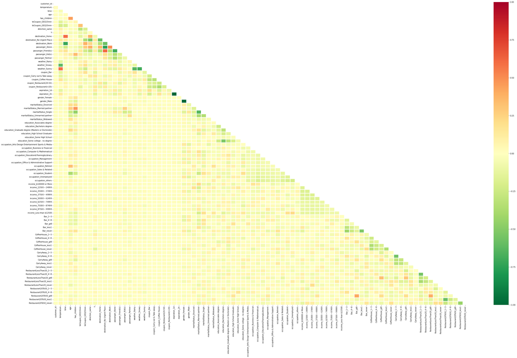

```python
# Check Multicollinearity relations ship between variables using pearson method
corr = data_train_dummies.corr(method='pearson')
mask = np.zeros_like(corr)
mask[np.triu_indices_from(mask)] = True
plt.figure(figsize = (50,30))
sns.heatmap(corr, cmap = 'RdYlGn_r', vmax = 1.0, vmin = -1.0, mask=mask,linewidths=2.5)
plt.yticks(rotation=0)
plt.xticks(rotation=90)
plt.savefig('Multicollinearity20220828.png')
```

#### ***In above analysis we have used the pearson method hence the values which are in between -1 and 1, hence all the

columns with 0 values can be removed based on the collinear relationship

Based on the analysis, we can remove the columns 'destination_Work', 'passanger_Alone', 'weather_Snowy', 'expiration_1d' 'maritalStatus_Married partner', gender_Female

```python
#Dropping the columns as indentified during Correlation analysis
data_train_dummies.drop(columns = ['customer_id','destination_Work','passanger_Alone','weather_Snowy','expiration_1d','maritalStatus_Married partner','gender_Female'],inplace=True)
data_test_dummies.drop(columns = ['customer_id','destination_Work','passanger_Alone','weather_Snowy','expiration_1d','maritalStatus_Married partner','gender_Female'],inplace=True)
```

## Data-Set in to features and Target for Model Building

```python
# Splitting the data in to feature and Target column
X_train  = np.array(data_train_dummies.drop(columns = 'Y'))
y_train  = np.array(data_train_dummies['Y'])
X_test   = np.array(data_test_dummies)
print(X_train.shape,y_train.shape,X_test.shape)
```

```
(10147, 76) (10147,) (2537, 76)
```

```python
#scaler = StandardScaler().fit(X)
#X_scaled = pd.DataFrame(scaler.transform(X),
#                              columns=X.columns,
#                              index=X.index)
#X_test_scaled = pd.DataFrame(scaler.transform(data_test_dummies),
#                              columns=data_test_dummies.columns,
#                              index=data_test_dummies.index)
#print(X_scaled,y.shape,X_test_scaled)
```

## Model Building Start with all possible Alogirthms

### Logistic Regression Model

```python
logreg = LogisticRegression()
logreg.fit(X_train, y_train)
#Y_pred = logreg.predict(X_test)
LR_cv_results_acc = cross_val_score(logreg, X_train, y_train, cv=5, scoring='accuracy')
print("%s k-fold Accuracy: %f (%f)" % ('LR', LR_cv_results_acc.mean(), LR_cv_results_acc.std()))
```

```
LR k-fold Accuracy: 0.681679 (0.001783)
```

### Support Vector Machines

```python
from sklearn import svm
svc = svm.SVC()
svc.fit(X_train, y_train)
SVM_cv_results_acc = cross_val_score(svc, X_train, y_train, cv=5, scoring='accuracy')
print("%s k-fold Accuracy: %f (%f)" % ('SVM', SVM_cv_results_acc.mean(), SVM_cv_results_acc.std()))
```

```
SVM k-fold Accuracy: 0.568444 (0.000182)
```

### Gaussian Naive Bayes

```python
gaussian = GaussianNB()
gaussian.fit(X_train, y_train)
NB_cv_results_acc = cross_val_score(gaussian, X_train, y_train, cv=5, scoring='accuracy')
print("%s k-fold Accuracy: %f (%f)" % ('NB', NB_cv_results_acc.mean(), NB_cv_results_acc.std()))
```

```
NB k-fold Accuracy: 0.641471 (0.006376)
```

### Decision Tree

```python
decision_tree = DecisionTreeClassifier()
decision_tree.fit(X_train, y_train)
DT_cv_results_acc = cross_val_score(decision_tree, X_train, y_train, cv=5, scoring='accuracy')
print("%s k-fold Accuracy: %f (%f)" % ('DT', DT_cv_results_acc.mean(), DT_cv_results_acc.std()))
```

```
DT k-fold Accuracy: 0.678427 (0.011405)
```

### K nearest Neighbors

```python
knn = KNeighborsClassifier(n_neighbors = 5)
knn.fit(X_train, y_train)
KNN_cv_results_acc = cross_val_score(knn, X_train, y_train, cv=5, scoring='accuracy')
print("%s k-fold Accuracy: %f (%f)" % ('KNN', KNN_cv_results_acc.mean(), KNN_cv_results_acc.std()))
```

```
KNN k-fold Accuracy: 0.629054 (0.011729)
```

### Random Forest

```python
random_forest = RandomForestClassifier()
random_forest.fit(X_train,y_train)
RF_cv_results_acc = cross_val_score(random_forest, X_train, y_train, cv=7, scoring='accuracy')
print("%s k-fold Accuracy: %f (%f)" % ('RF', RF_cv_results_acc.mean(), RF_cv_results_acc.std()))
```

```
RF k-fold Accuracy: 0.763968 (0.009767)
```

### Best Score Out of All Algorithms are follow

```python
models = {
    'Model': ['Support Vector Machines',
              'Logistic Regression',
              'Random Forest',
              'Naive Bayes',
              'Decision Tree',
               'KNN'],

     'Cross ValidationScore_before': [

              SVM_cv_results_acc.mean(),
              LR_cv_results_acc.mean(),
              RF_cv_results_acc.mean(),
              NB_cv_results_acc.mean(),
              DT_cv_results_acc.mean(),
              KNN_cv_results_acc.mean()]


}
models = pd.DataFrame.from_dict(models, orient='index')
models = models.transpose()
models['Features']=len(data_train_dummies.columns)
models.sort_values(by=['Cross ValidationScore_before'],ascending=False).head(5)
```

|  | Model | Cross ValidationScore_before | Features |
| --- | --- | --- | --- |
| 2 | Random Forest | 0.763968 | 77 |
| 1 | Logistic Regression | 0.681679 | 77 |
| 4 | Decision Tree | 0.678427 | 77 |
| 3 | Naive Bayes | 0.641471 | 77 |
| 5 | KNN | 0.629054 | 77 |

### Hypertuning

- 1. **RandomizedSearchCV** is used to narrow down the search so that same can be applied in Grid Search

```python
params = {'n_estimators':list(range(3,400)),
          'criterion':['gini', 'entropy']}

clf = RandomForestClassifier()

random_forest = RandomizedSearchCV(estimator = clf, param_distributions=params,cv=5, n_iter=10, scoring='accuracy', random_state=88)

random_forest.fit(X_train,y_train)

y_pred = random_forest.predict(X_test)

#lf_cv_results_acc = cross_val_score(random_forest, X_train, y_train, cv=7, scoring='accuracy')
#print("%s k-fold Accuracy: %f (%f)" % ('RF', clf_cv_results_acc.mean(), clf_cv_results_acc.std()))

print("Tuned Hyperparameters :", random_forest.best_params_)
print("Accuracy :",random_forest.best_score_)



df_results=pd.DataFrame(random_forest.cv_results_)
df_results.sort_values(by='mean_test_score', ascending=False)[['param_n_estimators','mean_test_score']].head()
```

```
Tuned Hyperparameters : {'n_estimators': 305, 'criterion': 'entropy'}
Accuracy : 0.7668281834580843
```

|  | param_n_estimators | mean_test_score |
| --- | --- | --- |
| 9 | 305 | 0.766828 |
| 4 | 273 | 0.766630 |
| 6 | 164 | 0.766434 |
| 1 | 297 | 0.766335 |
| 7 | 128 | 0.765546 |

### 2. GridSearchCV

```python
params = {'bootstrap' : [False],
          'n_estimators':list(range(280,310)),
          'criterion':['entropy']}

clf = RandomForestClassifier(random_state=88)
random_forest_grid = GridSearchCV(clf, param_grid = params, cv = 5, scoring = 'accuracy', n_jobs=-1)

random_forest_grid.fit(X_train,y_train)

y_pred_grid = random_forest_grid.predict(X_test)

print("Tuned Hyperparameters :", random_forest_grid.best_params_)
print("Accuracy :",random_forest_grid.best_score_)

df_results1=pd.DataFrame(random_forest_grid.cv_results_)
df_results1.sort_values(by='mean_test_score', ascending=False)[['param_n_estimators','mean_test_score']].head()
```

```
Tuned Hyperparameters : {'bootstrap': False, 'criterion': 'entropy', 'n_estimators': 292}
Accuracy : 0.7696840695298608
```

|  | param_n_estimators | mean_test_score |
| --- | --- | --- |
| 12 | 292 | 0.769684 |
| 9 | 289 | 0.769487 |
| 14 | 294 | 0.769290 |
| 11 | 291 | 0.769093 |
| 2 | 282 | 0.768994 |

```python
print("The Accuracy score of the model using Random Search is: %.2f%%" % (df_results[df_results['param_n_estimators']==305]['mean_test_score']*100))

print("The Accuracy score of the model using Grid search is: %.2f%%" % (df_results1[df_results1['param_n_estimators']==292]['mean_test_score']*100))

#print("%sK-fold Accuracy: %f (%f)" % ('With Grid Search :', CV_Grid.mean(), CV_Grid.std()))
```

```
The Accuracy score of the model using Random Search is: 76.68%
The Accuracy score of the model using Grid search is: 76.97%
```

- Based on the above Case as CV score of **Grid Search** is comming max so same model used for predcition of Test data set.

```python
data_test_=pd.read_csv('test.csv')
submission = pd.DataFrame({
        "CustomerID": data_test_["customer_id"],
        "Y": y_pred_grid # Based on the above Case as CV score of Grid Search is comming max so same model
                         # used for predcition of Test data set
    })

submission.to_csv('submission.csv', index=False)
submission
```

|  | CustomerID | Y |
| --- | --- | --- |
| 0 | 374679 | 1 |
| 1 | 469678 | 1 |
| 2 | 216140 | 0 |
| 3 | 184301 | 0 |
| 4 | 148720 | 1 |
| ... | ... | ... |
| 2532 | 356045 | 0 |
| 2533 | 498759 | 1 |
| 2534 | 356159 | 0 |
| 2535 | 218541 | 0 |
| 2536 | 467387 | 1 |

2537 rows × 2 columns

### Conclusion

- The test accuracy of the model is **76.11%** after submission of model. **TEAM DEEP DIVERS**.

[figure not shown]